# NBA SEASON 2022-23

## Part I: Importing the Python Packages

```python
import numpy as np
import pandas as pd
import matplotlib.pyplot as plt
import seaborn as sns
from mpl_toolkits.mplot3d import Axes3D
```

## Part II: Loading the Data

In this part i am loading the NBA 2022-23 season player data from a comma separated values (csv) file into a data frame.

```python
dataset_path = './Data/playerStats22.csv'
Season = pd.read_csv(dataset_path)
```

To view the first five lines of the csv file `head` command is appropriate.

(Unlimiting the `display.max_columns` parameter is a way to unlock the full view horizontally.)

```python
pd.set_option('display.max_columns', None)
Season.head(5)
```

|  | Rk | Player | Pos | Age | Tm | G | GS | MP | FG | FGA | FG% | 3P | 3PA | 3P% | 2P | 2PA | 2P% | eFG% | FT | FTA | FT% | ORB | DRB | TRB | AST | STL | BLK | TOV | PF | … |
| --- | --- | --- | --- | --- | --- | --- | --- | --- | --- | --- | --- | --- | --- | --- | --- | --- | --- | --- | --- | --- | --- | --- | --- | --- | --- | --- | --- | --- | --- | --- |
| 0 | 1 | Precious Achiuwa | C | 23 | TOR | 55 | 12 | 20.7 | 3.6 | 7.3 | 0.485 | 0.5 | 2.0 | 0.269 | 3.0 | 5.4 | 0.564 | 0.521 | 1.6 | 2.3 | 0.702 | 1.8 | 4.1 | 6.0 | 0.9 | 0.6 | 0.5 | 1.1 | 1.9 | … |
| 1 | 2 | Steven Adams | C | 29 | MEM | 42 | 42 | 27.0 | 3.7 | 6.3 | 0.597 | 0.0 | 0.0 | 0.000 | 3.7 | 6.2 | 0.599 | 0.597 | 1.1 | 3.1 | 0.364 | 5.1 | 6.5 | 11.5 | 2.3 | 0.9 | 1.1 | 1.9 | 2.3 | … |
| 2 | 3 | Bam Adebayo | C | 25 | MIA | 75 | 75 | 34.6 | 8.0 | 14.9 | 0.540 | 0.0 | 0.2 | 0.083 | 8.0 | 14.7 | 0.545 | 0.541 | 4.3 | 5.4 | 0.806 | 2.5 | 6.7 | 9.2 | 3.2 | 1.2 | 0.8 | 2.5 | 2.8 | … |
| 3 | 4 | Ochai Agbaji | SG | 22 | UTA | 59 | 22 | 20.5 | 2.8 | 6.5 | 0.427 | 1.4 | 3.9 | 0.355 | 1.4 | 2.7 | 0.532 | 0.532 | 0.9 | 1.2 | 0.812 | 0.7 | 1.3 | 2.1 | 1.1 | 0.3 | 0.3 | 0.7 | 1.7 | … |
| 4 | 5 | Santi Aldama | PF | 22 | MEM | 77 | 20 | 21.8 | 3.2 | 6.8 | 0.470 | 1.2 | 3.5 | 0.353 | 2.0 | 3.4 | 0.591 | 0.560 | 1.4 | 1.9 | 0.750 | 1.1 | 3.7 | 4.8 | 1.3 | 0.6 | 0.6 | 0.8 | 1.9 | … |

## Part III: Preparing the data

Best way to check the sizes of the dataframe is the `shape` function, which returns with a pair consisting of the number of rows and columns in the dataframe.

```python
Season.shape
```

```
(679, 31)
```

The function `columns` shows the name of the columns.

```python
Season.columns
```

```
Index(['Rk', 'Player', 'Pos', 'Age', 'Tm', 'G', 'GS', 'MP', 'FG', 'FGA', 'FG%',
       '3P', '3PA', '3P%', '2P', '2PA', '2P%', 'eFG%', 'FT', 'FTA', 'FT%',
       'ORB', 'DRB', 'TRB', 'AST', 'STL', 'BLK', 'TOV', 'PF', 'PTS',
       'Player-additional'],
      dtype='object')
```

The function `dtypes` shows the type of the columns.

```python
Season.dtypes
```

```
Rk                     int64
Player                object
Pos                   object
Age                    int64
Tm                    object
G                      int64
GS                     int64
MP                   float64
FG                   float64
FGA                  float64
FG%                  float64
3P                   float64
3PA                  float64
3P%                  float64
2P                   float64
2PA                  float64
2P%                  float64
eFG%                 float64
FT                   float64
FTA                  float64
FT%                  float64
ORB                  float64
DRB                  float64
TRB                  float64
AST                  float64
STL                  float64
BLK                  float64
TOV                  float64
PF                   float64
PTS                  float64
Player-additional     object
dtype: object
```

Combaining `isnull` and `sum` functions the right way i can get the number of NaNs in the dataframe and also the number of them per column.

In this dataframe NaNs can be valuable information because it is possible for a player to lacking a single successive 3-point shot so i will not edit them.

```python
print("Number of NaNs in the dataframe: {0}".format(Season.isnull().sum().sum()))
print("Number of NaNs per column:")
NaNs_per_column = Season.isnull().sum()
NaNs_per_column
#Season.isnull().sum().sum()
```

```
Number of NaNs in the dataframe: 74
Number of NaNs per column:
```

```
Rk                    0
Player                0
Pos                   0
Age                   0
Tm                    0
G                     0
GS                    0
MP                    0
FG                    0
FGA                   0
FG%                   3
3P                    0
3PA                   0
3P%                  24
2P                    0
2PA                   0
2P%                   7
eFG%                  3
FT                    0
FTA                   0
FT%                  37
ORB                   0
DRB                   0
TRB                   0
AST                   0
STL                   0
BLK                   0
TOV                   0
PF                    0
PTS                   0
Player-additional     0
dtype: int64
```

Getting rid of useless column(s) with `drop` function.

```python
Season.drop('Rk', axis=1, inplace=True)
```

Renaming a column for more comfortable and meaningful version with `rename` function.

```python
Season.rename(columns={'Player-additional':'playerID'}, inplace=True)
Season.head(10)
```

|  | Player | Pos | Age | Tm | G | GS | MP | FG | FGA | FG% | 3P | 3PA | 3P% | 2P | 2PA | 2P% | eFG% | FT | FTA | FT% | ORB | DRB | TRB | AST | STL | BLK | TOV | PF | PTS | … |
| --- | --- | --- | --- | --- | --- | --- | --- | --- | --- | --- | --- | --- | --- | --- | --- | --- | --- | --- | --- | --- | --- | --- | --- | --- | --- | --- | --- | --- | --- | --- |
| 0 | Precious Achiuwa | C | 23 | TOR | 55 | 12 | 20.7 | 3.6 | 7.3 | 0.485 | 0.5 | 2.0 | 0.269 | 3.0 | 5.4 | 0.564 | 0.521 | 1.6 | 2.3 | 0.702 | 1.8 | 4.1 | 6.0 | 0.9 | 0.6 | 0.5 | 1.1 | 1.9 | 9.2 | … |
| 1 | Steven Adams | C | 29 | MEM | 42 | 42 | 27.0 | 3.7 | 6.3 | 0.597 | 0.0 | 0.0 | 0.000 | 3.7 | 6.2 | 0.599 | 0.597 | 1.1 | 3.1 | 0.364 | 5.1 | 6.5 | 11.5 | 2.3 | 0.9 | 1.1 | 1.9 | 2.3 | 8.6 | … |
| 2 | Bam Adebayo | C | 25 | MIA | 75 | 75 | 34.6 | 8.0 | 14.9 | 0.540 | 0.0 | 0.2 | 0.083 | 8.0 | 14.7 | 0.545 | 0.541 | 4.3 | 5.4 | 0.806 | 2.5 | 6.7 | 9.2 | 3.2 | 1.2 | 0.8 | 2.5 | 2.8 | 20.4 | … |
| 3 | Ochai Agbaji | SG | 22 | UTA | 59 | 22 | 20.5 | 2.8 | 6.5 | 0.427 | 1.4 | 3.9 | 0.355 | 1.4 | 2.7 | 0.532 | 0.532 | 0.9 | 1.2 | 0.812 | 0.7 | 1.3 | 2.1 | 1.1 | 0.3 | 0.3 | 0.7 | 1.7 | 7.9 | … |
| 4 | Santi Aldama | PF | 22 | MEM | 77 | 20 | 21.8 | 3.2 | 6.8 | 0.470 | 1.2 | 3.5 | 0.353 | 2.0 | 3.4 | 0.591 | 0.560 | 1.4 | 1.9 | 0.750 | 1.1 | 3.7 | 4.8 | 1.3 | 0.6 | 0.6 | 0.8 | 1.9 | 9.0 | … |
| 5 | Nickeil Alexander-Walker | SG | 24 | TOT | 59 | 3 | 15.0 | 2.2 | 5.0 | 0.444 | 1.0 | 2.7 | 0.384 | 1.2 | 2.3 | 0.515 | 0.547 | 0.7 | 1.0 | 0.667 | 0.3 | 1.5 | 1.7 | 1.8 | 0.5 | 0.4 | 0.9 | 1.5 | 6.2 | … |
| 6 | Nickeil Alexander-Walker | SG | 24 | UTA | 36 | 3 | 14.7 | 2.3 | 4.7 | 0.488 | 1.0 | 2.4 | 0.402 | 1.3 | 2.3 | 0.578 | 0.591 | 0.8 | 1.1 | 0.692 | 0.2 | 1.4 | 1.6 | 2.1 | 0.7 | 0.4 | 1.3 | 1.6 | 6.3 | … |
| 7 | Nickeil Alexander-Walker | SG | 24 | MIN | 23 | 0 | 15.5 | 2.1 | 5.4 | 0.384 | 1.1 | 3.1 | 0.361 | 1.0 | 2.3 | 0.415 | 0.488 | 0.6 | 0.9 | 0.619 | 0.3 | 1.5 | 1.8 | 1.4 | 0.3 | 0.3 | 0.4 | 1.3 | 5.9 | … |
| 8 | Grayson Allen | SG | 27 | MIL | 72 | 70 | 27.4 | 3.4 | 7.7 | 0.440 | 2.0 | 5.1 | 0.399 | 1.4 | 2.7 | 0.518 | 0.571 | 1.6 | 1.8 | 0.905 | 0.8 | 2.4 | 3.3 | 2.3 | 0.9 | 0.2 | 1.0 | 1.6 | 10.4 | … |
| 9 | Jarrett Allen | C | 24 | CLE | 68 | 68 | 32.6 | 5.9 | 9.2 | 0.644 | 0.0 | 0.1 | 0.100 | 5.9 | 9.1 | 0.653 | 0.645 | 2.4 | 3.3 | 0.733 | 3.3 | 6.5 | 9.8 | 1.7 | 0.8 | 1.2 | 1.4 | 2.3 | 14.3 | … |

## Part IV: Analyzing the Data

Representing the first 10 players' name and id.

There is a name appearing 3 times with the same id, but different teams which is imortant information. There are players that changed teams during season and their stats are recorded with each team seperately and combined too. ( **TOT** means total)

```python
name_of_first_ten = Season['Player'][0:10]
id_of_first_ten = Season['playerID'][0:10]
team_of_first_ten = Season['Tm'][0:10]

i = 0
while i < len(name_of_first_ten):
    print("{0}. name: {1} - team: {2} - id:{3}".format(i+1, name_of_first_ten[i], team_of_first_ten[i], id_of_first_ten[i]))
    i = i + 1
```

```
1. name: Precious Achiuwa - team: TOR - id:achiupr01
2. name: Steven Adams - team: MEM - id:adamsst01
3. name: Bam Adebayo - team: MIA - id:adebaba01
4. name: Ochai Agbaji - team: UTA - id:agbajoc01
5. name: Santi Aldama - team: MEM - id:aldamsa01
6. name: Nickeil Alexander-Walker - team: TOT - id:alexani01
7. name: Nickeil Alexander-Walker - team: UTA - id:alexani01
8. name: Nickeil Alexander-Walker - team: MIN - id:alexani01
9. name: Grayson Allen - team: MIL - id:allengr01
10. name: Jarrett Allen - team: CLE - id:allenja01
```

The `describe` function computes a summary of statistics pertaining to the DataFrame columns. This function gives the mean, std and IQR values.

```python
#pd.set_option('display.max_columns', None)
#pd.reset_option('display.max_columns')
Season.describe()
```

|  | Age | G | GS | MP | FG | FGA | FG% | 3P | 3PA | 3P% | 2P | 2PA | 2P% | eFG% | FT | FTA | FT% | ORB | DRB | TRB | AST | STL | BLK | TOV | PF | PTS |
| --- | --- | --- | --- | --- | --- | --- | --- | --- | --- | --- | --- | --- | --- | --- | --- | --- | --- | --- | --- | --- | --- | --- | --- | --- | --- | --- |
| count | 679.000000 | 679.000000 | 679.000000 | 679.000000 | 679.000000 | 679.000000 | 676.000000 | 679.000000 | 679.000000 | 655.000000 | 679.000000 | 679.000000 | 672.000000 | 676.000000 | 679.000000 | 679.000000 | 642.000000 | 679.000000 | 679.000000 | 679.000000 | 679.000000 | 679.000000 | 679.000000 | 679.000000 | 679.000000 | 679.000000 |
| mean | 26.025037 | 43.337261 | 20.069219 | 19.464212 | 3.249337 | 6.921060 | 0.464241 | 0.996613 | 2.783063 | 0.329798 | 2.254934 | 4.138439 | 0.532638 | 0.535314 | 1.366568 | 1.768630 | 0.752586 | 0.842268 | 2.620324 | 3.461708 | 2.011782 | 0.601767 | 0.370545 | 1.067305 | 1.660825 | 8.859057 |
| std | 4.325709 | 24.729145 | 25.766359 | 9.415320 | 2.362501 | 4.795565 | 0.112790 | 0.862033 | 2.209284 | 0.128238 | 1.906812 | 3.380376 | 0.138174 | 0.108737 | 1.478315 | 1.793762 | 0.150094 | 0.731867 | 1.715881 | 2.281077 | 1.891335 | 0.392063 | 0.367465 | 0.799478 | 0.770299 | 6.630944 |
| min | 19.000000 | 1.000000 | 0.000000 | 1.000000 | 0.000000 | 0.000000 | 0.000000 | 0.000000 | 0.000000 | 0.000000 | 0.000000 | 0.000000 | 0.000000 | 0.000000 | 0.000000 | 0.000000 | 0.000000 | 0.000000 | 0.000000 | 0.000000 | 0.000000 | 0.000000 | 0.000000 | 0.000000 | 0.000000 | 0.000000 |
| 25% | 23.000000 | 22.000000 | 0.000000 | 12.150000 | 1.500000 | 3.400000 | 0.415000 | 0.300000 | 1.000000 | 0.297000 | 0.900000 | 1.700000 | 0.485000 | 0.496000 | 0.400000 | 0.600000 | 0.686500 | 0.300000 | 1.400000 | 1.800000 | 0.800000 | 0.300000 | 0.100000 | 0.500000 | 1.200000 | 4.100000 |
| 50% | 25.000000 | 45.000000 | 6.000000 | 18.800000 | 2.600000 | 5.700000 | 0.454000 | 0.800000 | 2.400000 | 0.349000 | 1.600000 | 3.100000 | 0.536000 | 0.537000 | 0.900000 | 1.200000 | 0.769000 | 0.700000 | 2.300000 | 3.000000 | 1.300000 | 0.500000 | 0.300000 | 0.900000 | 1.600000 | 6.900000 |
| 75% | 29.000000 | 65.500000 | 36.500000 | 27.550000 | 4.200000 | 9.200000 | 0.506000 | 1.500000 | 4.150000 | 0.389000 | 3.000000 | 5.550000 | 0.594250 | 0.579250 | 1.700000 | 2.300000 | 0.844750 | 1.100000 | 3.400000 | 4.500000 | 2.700000 | 0.800000 | 0.500000 | 1.400000 | 2.200000 | 11.550000 |
| max | 42.000000 | 83.000000 | 83.000000 | 41.000000 | 11.200000 | 22.200000 | 1.000000 | 4.900000 | 11.400000 | 1.000000 | 10.500000 | 17.800000 | 1.000000 | 1.000000 | 10.000000 | 12.300000 | 1.000000 | 5.100000 | 9.600000 | 12.500000 | 10.700000 | 3.000000 | 3.000000 | 4.100000 | 5.000000 | 33.100000 |

I am using the function `value_counts` to summarize the number of players by position, then `print` to display the content of the *CountPos* variable.

After that i am creating a new version without the negligible values.

```python
CountPos = Season['Pos'].value_counts().to_dict()
print(CountPos)

moreThanOnePercent = CountPos.copy()
keys_copy = list(moreThanOnePercent.keys())

def is_relevant_position(score):
    return score > len(Season) / 100

for x in keys_copy:
    if is_relevant_position(moreThanOnePercent[x]) == False:
        moreThanOnePercent.pop(x)
```

```
{'SG': 162, 'C': 139, 'SF': 133, 'PF': 121, 'PG': 115, 'SG-PG': 2, 'SF-SG': 2, 'PG-SG': 2, 'SF-PF': 1, 'PF-C': 1, 'PF-SF': 1}
```

According to the NBA the players have to play at 58 games out of the 82 to qualify for specific statistical comparisons, but i am setting the minimum at 2/3 of the season which is 55 games.

```python
min_55_games = Season.query("G >= 55")
min_55_games.shape
```

```
(273, 30)
```

## Part V: Presenting the Data

Representing the distribution of player positions on a pie chart.

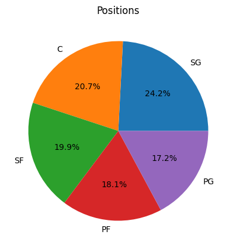

```python
fig = plt.figure(figsize=(5, 5))
plt.pie(moreThanOnePercent.values(), labels=moreThanOnePercent.keys(), autopct='%1.1f%%')
plt.title("Positions")
plt.show()
```

Using histogram i can represent graphically the distribution of players in different categories like Games Played, Minutes Per Game, Age, Points Per Game.

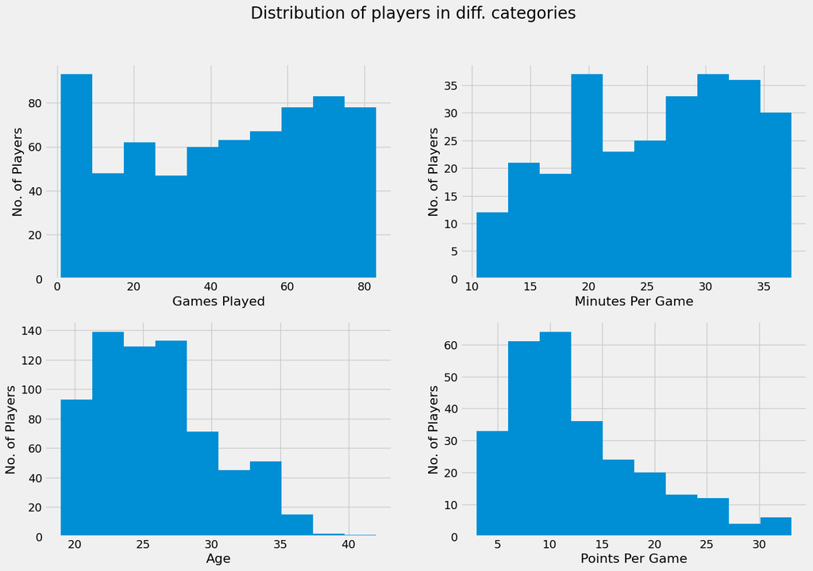

```python
with plt.style.context('fivethirtyeight'):

    n_bins = 10

    fig, ax = plt.subplots(2, 2, figsize=(15, 10))
    fig.suptitle('Distribution of players in diff. categories', fontsize=20)

    ax[0][0].hist(Season['G'], bins = n_bins)
    ax[0][0].set_xlabel('Games Played', fontsize=16)
    ax[0][0].set_ylabel('No. of Players', fontsize=16)

    ax[0][1].hist(min_55_games['MP'], bins = n_bins)
    ax[0][1].set_xlabel('Minutes Per Game', fontsize=16)
    ax[0][1].set_ylabel('No. of Players', fontsize=16)

    ax[1][0].hist(Season['Age'], bins = n_bins)
    ax[1][0].set_xlabel('Age', fontsize=16)
    ax[1][0].set_ylabel('No. of Players', fontsize=16)

    ax[1][1].hist(min_55_games['PTS'], bins = n_bins)
    ax[1][1].set_xlabel('Points Per Game', fontsize=16)
    ax[1][1].set_ylabel('No. of Players', fontsize=16)
```

After determining 3 age groups (19-24, 25-29, 30+) and a quick counting I can represent the number of players each team have in the age groups respectively.  
Furthermore a pie chart representing the distribution of age groups in the league is added.

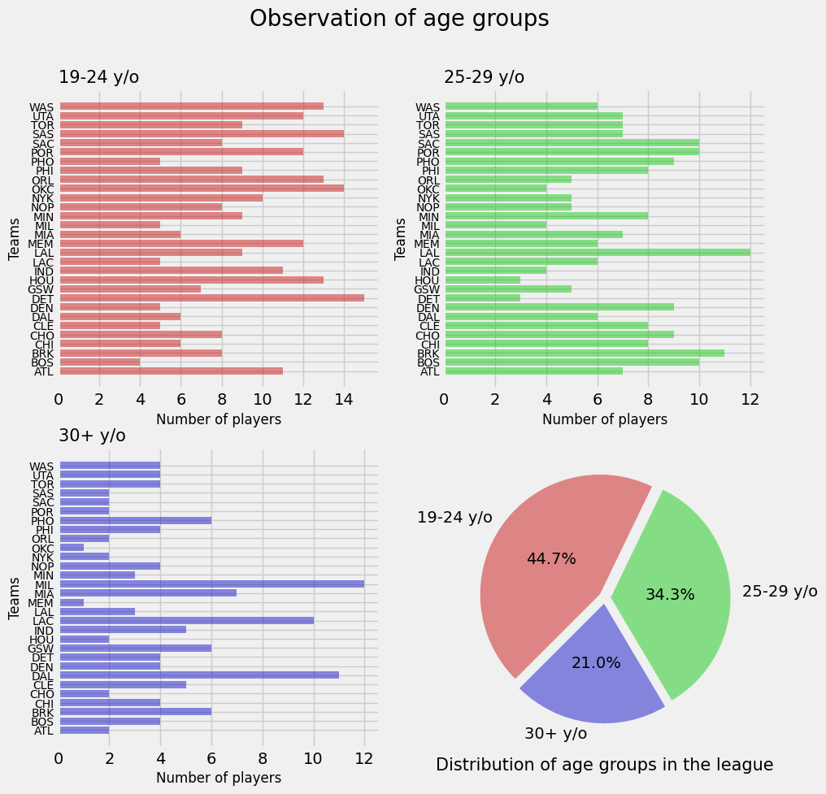

```python
withoutTOT = (Season.query("Tm != 'TOT'")).sort_values(by='Age', ascending=True)

teams = np.unique(withoutTOT['Tm'])

zeros = []
for i in range(0,len(teams)):
    zeros.insert(i,0)

first_dict = dict(zip(teams,zeros))
second_dict = dict(zip(teams,zeros))
third_dict = dict(zip(teams,zeros))

num_of_first = 0
num_of_second = 0
num_of_third = 0

for ind in withoutTOT.index:
    if withoutTOT['Age'][ind] <= 24:
        x = first_dict.get(withoutTOT['Tm'][ind])
        first_dict[withoutTOT['Tm'][ind]] = x + 1
        num_of_first = num_of_first + 1
    elif withoutTOT['Age'][ind] > 24 and withoutTOT['Age'][ind] <= 29:
        y = second_dict.get(withoutTOT['Tm'][ind])
        second_dict[withoutTOT['Tm'][ind]] = y + 1
        num_of_second = num_of_second + 1
    else:
        z = third_dict.get(withoutTOT['Tm'][ind])
        third_dict[withoutTOT['Tm'][ind]] = z + 1
        num_of_third = num_of_third + 1


with plt.style.context('fivethirtyeight'):

    y_pos = np.arange(len(teams))

    fig, ax = plt.subplots(2, 2, figsize=(10,10),
                           gridspec_kw={'height_ratios' : [1,1], 'width_ratios' : [1,1]}
                           )
    fig.suptitle('Observation of age groups', fontsize=20)

    ax[0][0].barh(y_pos, first_dict.values(), align='center', alpha=0.5, color=(0.8, 0.1, 0.1, 0.5))
    ax[0][0].set_title('19-24 y/o', fontsize=15, loc='left')
    ax[0][0].set_xlabel('Number of players', fontsize=12)
    ax[0][0].set_ylabel('Teams', fontsize=12)
    ax[0][0].set_yticks(y_pos, first_dict.keys(), fontsize=10)

    ax[0][1].barh(y_pos, second_dict.values(), align='center', alpha=0.5, color=(0.1, 0.8, 0.1, 0.5))
    ax[0][1].set_title('25-29 y/o', fontsize=15, loc='left')
    ax[0][1].set_xlabel('Number of players', fontsize=12)
    ax[0][1].set_ylabel('Teams', fontsize=12)
    ax[0][1].set_yticks(y_pos, second_dict.keys(), fontsize=10)

    ax[1][0].barh(y_pos, third_dict.values(), align='center', alpha=0.5, color=(0.1, 0.1, 0.8, 0.5))
    ax[1][0].set_title('30+ y/o', fontsize=15, loc='left')
    ax[1][0].set_xlabel('Number of players', fontsize=12)
    ax[1][0].set_ylabel('Teams', fontsize=12)
    ax[1][0].set_yticks(y_pos, third_dict.keys(), fontsize=10)

    #ax[1][1].set_visible(False)
    labels =[ '19-24 y/o', '25-29 y/o', '30+ y/o']
    sizes = [num_of_first, num_of_second, num_of_third]
    colors = [(0.8, 0.1, 0.1, 0.5), (0.1, 0.8, 0.1, 0.5), (0.1, 0.1, 0.8, 0.5)]
    ax[1][1].pie(sizes, labels = labels, autopct='%1.1f%%', pctdistance=0.5, labeldistance=1.1, explode=(0.05, 0.05, 0.05), colors = colors , counterclock = False, startangle = 225)
    #ax[1][1].legend()
    ax[1][1].set_title('Distribution of age groups in the league', fontsize=15, y=-0.1, fontdict={'horizontalalignment':'center'})
```

Representing players' *3-point attemps* and *made 3-pointers* per game on a scatter diagram.

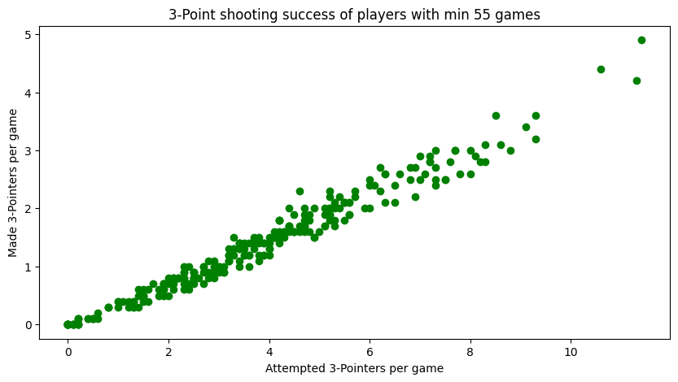

```python
#print(min_55_games.sort_values(by='3P', ascending=False)['Player'][0:3])

fig = plt.figure(figsize=(10, 5))
plt.plot(min_55_games['3PA'], min_55_games['3P'], 'go')
plt.xlabel('Attempted 3-Pointers per game')
plt.ylabel('Made 3-Pointers per game')
plt.title('3-Point shooting success of players with min 55 games')
plt.show()
```

Representing players' *assists* and *turnovers* per game on a scatter diagram.

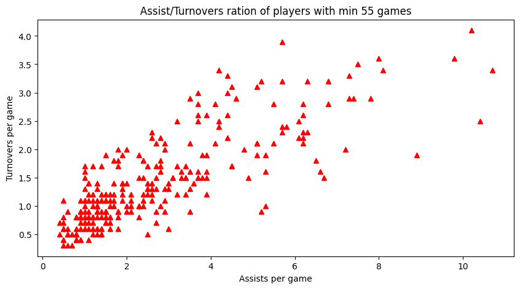

```python
fig = plt.figure(figsize=(10, 5))
plt.plot( min_55_games['AST'] , min_55_games['TOV'] , 'r^')
plt.xlabel('Assists per game')
plt.ylabel('Turnovers per game')
plt.title('Assist/Turnovers ration of players with min 55 games')
plt.show()
```

Representing players' *points* and *free throws* per game on a scatter diagram.

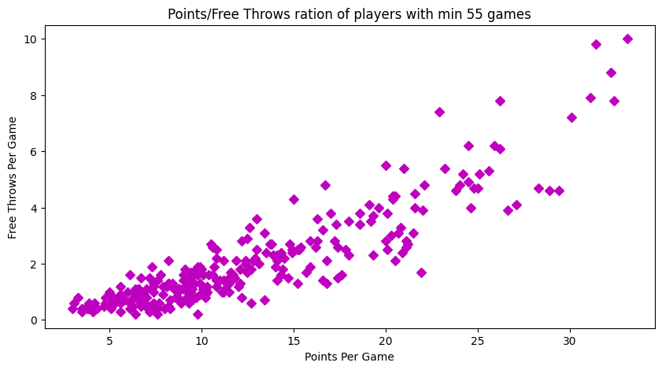

```python
fig = plt.figure(figsize=(10, 5))
plt.plot( min_55_games['PTS'] , min_55_games['FT'] , 'mD')
plt.xlabel('Points Per Game')
plt.ylabel('Free Throws Per Game')
plt.title('Points/Free Throws ration of players with min 55 games')
plt.show()
```

Representing players' *2-pointers*, *3-pointers* and *free throws* made per game on a 3D scatter diagram.

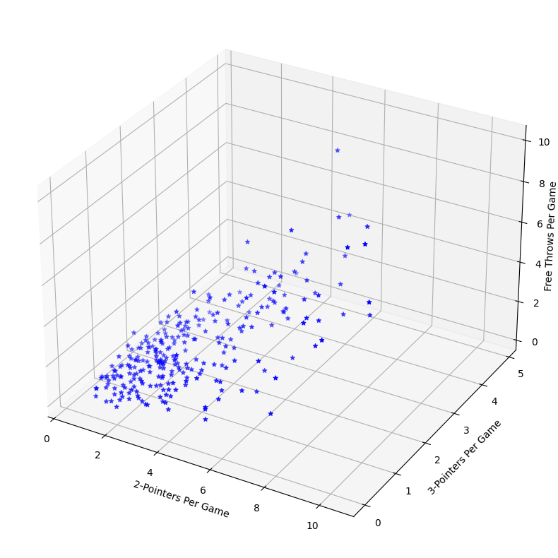

```python
# for creating a responsive plot
#%matplotlib widget
#%matplotlib notebook

fig = plt.figure(figsize=(10,10))
#ax = Axes3D(fig)

ax = plt.axes(projection='3d')

plot_cube = ax.scatter(min_55_games['2P'], min_55_games['3P'], min_55_games['FT'], marker='*', color='b')

ax.set_xlabel('2-Pointers Per Game')
ax.set_ylabel('3-Pointers Per Game')
ax.set_zlabel('Free Throws Per Game')
ax.zaxis.labelpad = -2.0

plt.show()
#ax.view_init(elev= -140, azim= 60, roll=-10)
```

**Plotting a correlation heatmap:**

1. Generating a correlation table based on the `without_duplicates` dataframe and storing it on `without_duplicates_corr`.
2. Using the `seaborn` `heatmap()` method to generate and plot the heatmap. Notice that `heatmap()` takes `without_duplicates_corr` as a parameter.

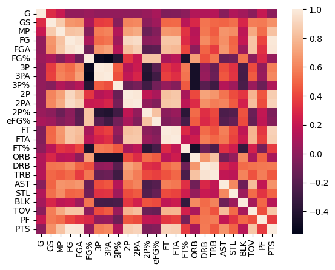

```python
without_duplicates = (min_55_games.drop_duplicates(subset='playerID'))

without_duplicates_corr = (without_duplicates.drop(['Player','Age', 'Pos', 'Tm', 'playerID'], axis=1, inplace=False)).corr()
sns.heatmap(without_duplicates_corr)
```

With the help of the correlation heatmap i can identify correlations way easier. For example *TOV* and *AST* have a strong correlation. I am trying to visualize the connection below.

First step is creating the plot. I will also assign assists as the independent variable $x$ and turnovers as the dependent variable $y$.

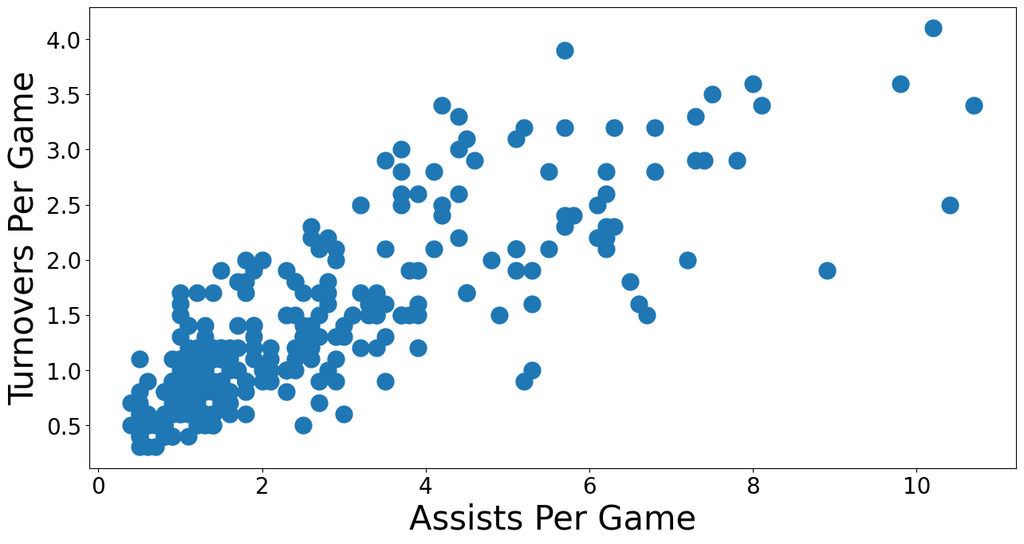

```python
# dependent variable for y axis
y = without_duplicates['TOV']
# independent variable for x axis
x = without_duplicates['AST']

# Display the plot inline
%matplotlib inline

# Increase the size of the plot
plt.figure(figsize=(15, 7.5))

# Create a scatter plot: Assists Per Game vs. Turnovers Per Game
plt.plot(x,y, 'o', markersize = 15)

# Add axis labels and increase the font size
plt.ylabel('Turnovers Per Game', fontsize = 30)
plt.xlabel('Assists Per Game', fontsize = 30)

# Increase the font size on the ticks on the x and y axis
plt.xticks(fontsize = 20)
plt.yticks(fontsize = 20)

# Display the scatter plot
plt.show()
```

Next step is generating a regresson line for the analyzed data, then calculating the centroid for this dataset is important (centroid is the mean for the dataset). The generated simple linear regression line must also pass through the centroid.

Calculating the slope and y-intercept of the linear reression line.

**y = m*x + b**

```python
# Use numpy polyfit for linear regression to fit the data
# Generate the slope of the line (m)
# Generate the y-intercept (b)
m, b = np.polyfit(x,y,1)
print ('The slope of line is {:.2f}.'.format(m))
print ('The y-intercept is {:.2f}.'.format(b))
print ('The best fit simple linear regression line is {:.2f}x + {:.2f}.'.format(m,b))
```

```
The slope of line is 0.32.
The y-intercept is 0.57.
The best fit simple linear regression line is 0.32x + 0.57.
```

Calculating the centroid by `mean` function.

```python
# y coordinate for centroid
y_mean = y.mean()
# x coordinate for centroid
x_mean = x.mean()
print ('The centroid for this dataset is x = {:.2f} and y = {:.2f}.'.format(x_mean, y_mean))
```

```
The centroid for this dataset is x = 2.75 and y = 1.44.
```

Overlaying the regression line and the centroid point on the plot.

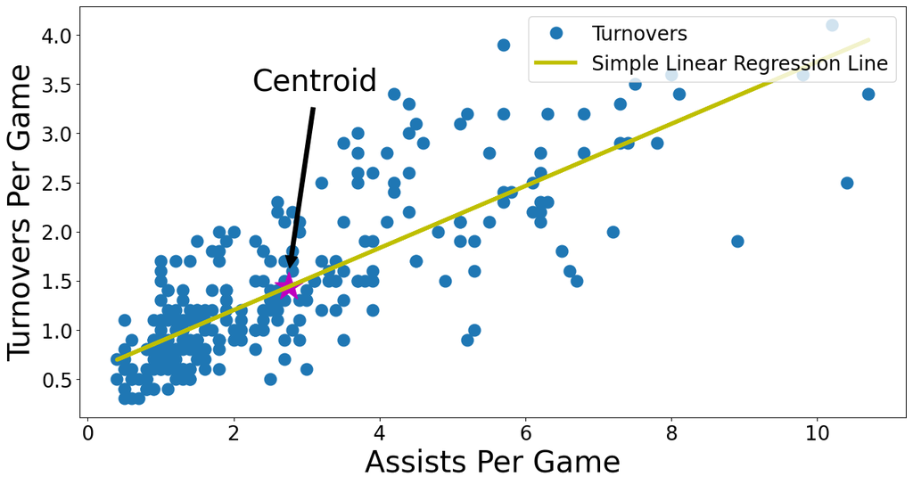

```python
# Create the plot inline
%matplotlib inline

# Enlarge the plot size
plt.figure(figsize=(15,7.5))

# Plot the scatter plot of the data set
plt.plot(x,y, 'o', markersize = 12, label = "Turnovers")

# Plot the centroid point
plt.plot(x_mean,y_mean, '*', markersize = 30, color = "m")

# Plot the linear regression line
plt.plot(x, m*x + b, '-', label = 'Simple Linear Regression Line', linewidth = 4, color='y')

# Create the x and y axis labels
plt.ylabel('Turnovers Per Game', fontsize = 30)
plt.xlabel('Assists Per Game', fontsize = 30)

# Enlarge x and y tick marks
plt.xticks(fontsize = 20)
plt.yticks(fontsize = 20)

# Point out the centroid point in the plot
plt.annotate('Centroid', xy=(x_mean, y_mean+0.1), xytext=(x_mean-0.5, y_mean+2), arrowprops=dict(facecolor='black', shrink=0.05), fontsize = 30)
#plt.annotate('asd', xy=(x_mean, y_mean), xytext=(x_mean, y_mean), arrowprops=dict(facecolor='black', shrink=0.05), fontsize = 30)

# Create legend
plt.legend(loc = 'upper right', fontsize = 20)
```

**Prediction**

Using the linear regression line, you can predict the number of turnovers per game based on the number of assists per game.

```python
# Function to predict the number of turnovers from the regression line
def predict(query):
    if query >= 1:
        predict = m * query + b
        return predict
    else:
        print ("You must have at least 1 assist to predict the number of turnovers.")
```

```python
# Enter the number of assists in the function to generate the turnovers prediction.
predict(6)
```

```
2.464714782473444
```